# Tvyal Newsletter

Aghasi Tavadyan

2024-06-28

*English summary below.*

Հարգելի գործընկեր,

Հուսով եմ՝ լավ եք: Ներկայացնում եմ այս շաբաթվա վերլուծությունները և աշխատանքները.

## [💰🚧⚖️ Պետական պարտքի ճոճանակ․ Առաջին անգամ ներքին պարտքը գերազանցում է արտաքինը](https://www.tvyal.com/newsletter/2024/2024_06_28)

Հայաստանի Հանրապետության պետական պարտքի կառուցվածքում առաջին անգամ ներքին պարտքի կշիռը գերազանցել է 50 տոկոսը։ 2024 թվականի մայիսի կտրվածքով կառավարության պետական պարտքը կազմել է 11 մլրդ 577 մլն դոլար կամ 4 տրիլիոն 496 մլրդ դրամ, որի 50.2 տոկոսը բաժին է ընկնումներքին աղբյուրներին, իսկ 49.8-ը՝ արտաքին։

Այս փոփոխությունը նշանակալի առաջընթաց է 2017 թվականի համեմատ, երբ Կառավարության ներքին պետական պարտքը կազմում էր ընդհանուր պարտքի 20.4 տոկոսը, իսկ արտաքինը՝ 79.6 տոկոսը։

**Գծապատկեր 1.**

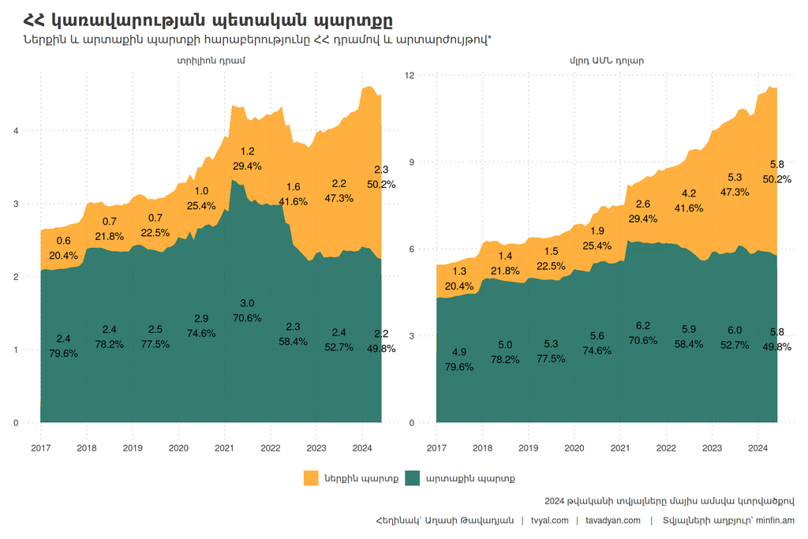

Վերջին տարիներին պետական պարտքի կառուցվածքում ներքին պարտքի մեծացման քաղաքականությունը իրականացվում է արտարժութային ռիսկերը զսպելու համար։ Նշենք, որ 2023 թվականի կտրվածքով պետական պարտք / ՀՆԱ հարաբերությունը կազմում է 48.1 տոկոս, որը դոլարի հանդեպ ՀՀ դրամի 20 կետով արժեզրկման պարագայում կհատի 50 տոկոսի սահմանը։ Ըստ ԵԱՏՄ համաձայնագրի 63-րդ կետի՝ ընդհանուր պետական պարտքը չպիտի գերազանցի համախառն ներքին արդյունքի 50 տոկոսը, իսկ ըստ հարկաբյուջետային գործող կանոնների՝ երբ Կառավարության պարտքը գերազանցում է ՀՆԱ-ի 60%-ը, գործադիրը պարտավորվում է ընթացիկ ծախսերը սահմանափակել, ինչպես նաև ներկայացնել ծրագիր՝ ՀՆԱ-ի նկատմամբ Կառավարության պարտքի մակարդակը նվազեցնելու վերաբերյալ։ ՀՀ ֆինանսների նախարարությունը իր միջնաժամկետ քաղաքականությունը իրականացնում է այնպես, որ պետական պարտք/ՀՆԱ հարաբերությունը պահպանի 50 տոկոսի շրջանակներում։

Գծապատկեր 2-ը ներկայացնում է պետական պարտքի կառուցվածքն ըստ ներքին և արտաքին պարտքի տեսակների:

**Գծապատկեր 2.**

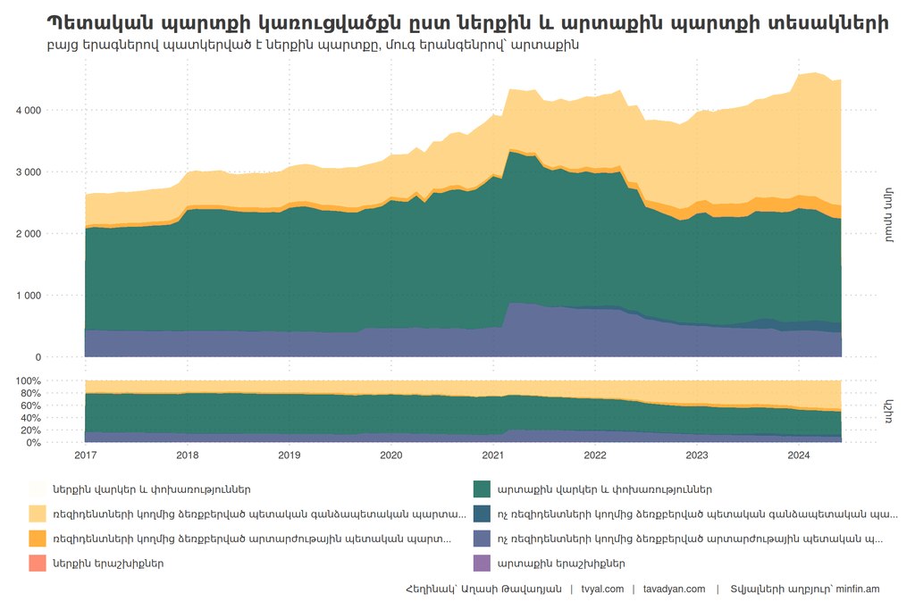

Կառավարության պարտքի միջին կշռված տոկոսադրույքը որոշակիորեն բարձրացել է՝ հասնելով 7.3 տոկոսի, ինչը հիմնականում պայմանավորված է այն հանգամանքով, որ ներքին դրամային պարտքերը, որոնք պետությունը ներգրավում է պարտատոմսեր թողարկելով, ավելի բարձր տոկոսադրույքով են։

Համաշխարհային ճգնաժամերը և աշխարհաքաղաքական կտրուկ փոփոխությունները կարող են հանգեցնել պետական պարտք / ՀՆԱ հարաբերության աճին, և ներքին պետական պարտքի մեծացման քաղաքականությունը զսպում է արտաքին ռիսկերը։

Կառավարության պարտքի 49.0 տոկոսը դրամով է, 29.9 տոկոսը՝ դոլարով, 9.1 տոկոսը՝ եվրոյով, մնացածը՝ այլ արժույթներով։

Ներքին պարտքի մեծացումը փոքրացնում է արտաքին ֆինանսական ռիսկերը։ Գծապատկեր 3-ը ցույց է տալիս պետական պարտքի սպասարկման և փոխարժեքի փոխկապվածությունը:

**Գծապատկեր 3.**

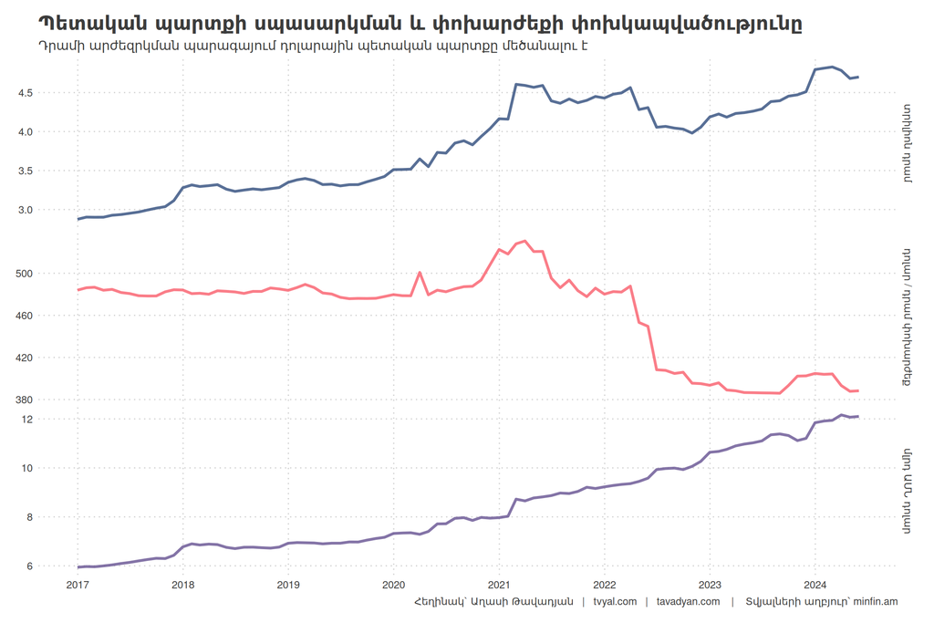

Ինչպես երևում է 4-րդ գծապատկերում, պետական պարտք/ՀՆԱ հարաբերությունը առաջին անգամ հատել է 50 տոկոսի սահմանագիծը 2016 թվականին՝ կազմելով 51.9 տոկոս։ Ս]ա հիմնականում պայմանավորված էր Ռուսաստանում արժութային ճգնաժամով, որի արդյունքում արժեզրկվեցին տարածաշրջանի բոլոր արժույթները, ինչպես նաև դրամը, որը կտրուկ մեծացրեց արտաքին պետական պարտքի սպասարկումը։ Տարեկան կտրվածքով պետական պարտք / ՀՆԱ հարաբերությունը առավելագույնի է հասել 2020 թվականին, երբ այն հատել է 63.5 տոկոսի սահմանագիծը, իսկ եռամսյակային կտրվածքով՝ 2021թ․ առաջին եռամսյակում՝ 69.8 տոկոս։ Նշենք, որ 2020 թվականին ՀՆԱ աճը բացասական էր՝ կազմելով -7.2 տոկոս, ինչը հիմնականում պայմանավորված էր հակահամաճարակային միջոցառումներով և 44-օրյա պատերազմով, որոնք նաև նպաստեցին պետական պարտքի աճին։

2022 թվականին պետական պարտք/ՀՆԱ հարաբերությունը հիմնականում կարողացավ իջնել ի հաշիվ դրամի արժևորման, որը պայմանավորված էր նրանով, որ 2022 թվականին Ռուսաստանի դեմ պատժամիջոցներով դրդված բավականին մեծ քանակությամբ արտարժութային միջոցներ մտան Հայաստան, ինչը արժևորեց դրամը, և, որպես հետևանք, իջեցրեց պետական պարտքի սպասարկումը։

Այս իրավիճակը ցույց է տալիս, որ արտաքին գործոնները կարող են էական ազդեցություն ունենալ Հայաստանի տնտեսության և պետական պարտքի դինամիկայի վրա: Սակայն պետք է նշել, որ նման իրավիճակները չեն կարող դիտարկվել որպես կայուն միտում, և երկարաժամկետ հեռանկարում անհրաժեշտ է ուշադրություն դարձնել պետական պարտքի կառավարման ավելի կայուն մեխանիզմների մշակմանը:

**Գծապատկեր 4.**

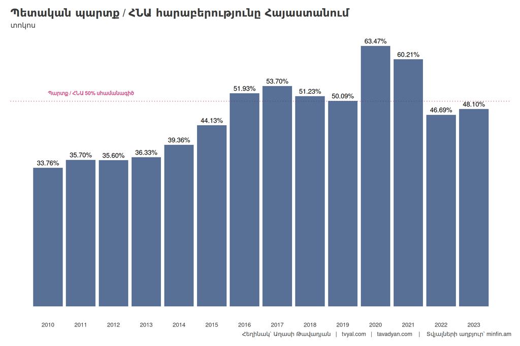

Վերջին գծապատկերում հստակ երևում է դոլարի փոխարժեքի ազդեցությունը պետական պարտքի սպասարկման և, որպես հետևանք, պետական պարտք/ՀՆԱ հարաբերության վրա։

Ինչքան արժևորվում է դրամը դոլարի հանդեպ, այնքան պետական պարտքի սպասարկումը էժանանում է, հետևաբար պետական պարտք/ՀՆԱ հարաբերությունը նվազում է, և հակառակը՝ որքան դրամը արժեզրկվում է, այնքան պետական պարտք/ՀՆԱ հարաբերությունը ունի աճի միտում։

Գծապատկերում երևում է նաև պետական պարտք/ՀՆԱ աճ փոխկապվածությունը, որը ունի հակադարձ ազդեցություն։ ՀՆԱ-ի բացասական աճի պարագայում պետական պարտքը կտրուկ աճում է, քանի որ ՀՆԱ-ի բացասական աճով չի կատարվում պետական բյուջեով սահմանված թիրախը, որի արդյունքում ստիպված սպառվում է բյուջեի պահուստային ֆոնդը և հետագայում նաև աճում է պետական պարտքը։

Այս միտումը վերջին գծապատկերում երևում է 2010 թվականին՝ 2002-2008 թվականների միջին 12 տոկոս տնտեսական աճից հետո։ Այս անկումը պայմանավորված էր Համաշխարհային ֆինանսական ճգնաժամով։ Նմանատիպ իրավիճակ դիտվեց նաև 2020 թվականին․ տնտեսական անկումը, այս անգամ, պայմանավորված էր մեկ այլ Համաշխարհային երևույթով՝ COVID-19 համաճարակով։ Արդյունքում երկու ճգնաժամերն էլ մեծացրեցին պետական պարտք/ՀՆԱ հարաբերությունը։

Այսինքն՝ դրամի փոխարժեքը ունի ուղղակի ազդեցություն պետական պարտքի աճի վրա, իսկ ՀՆԱ-ի աճը՝ հակադարձ։ Վերջին 25 տարիների ընթացքում բացասական ՀՆԱ-ի աճը հիմնականում պայմանավորված է եղել համաշխարհային “սև կարապ” իրադարձություններով։

**Գծապատկեր 5.**

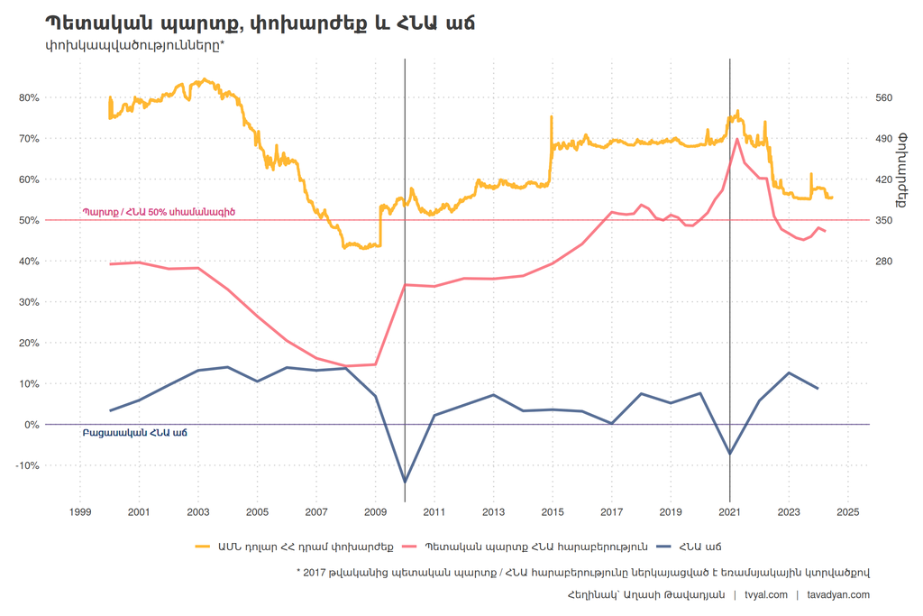

Այս վերլուծությունը ցույց է տալիս, որ Հայաստանի տնտեսությունը զգայուն է գլոբալ շոկերի նկատմամբ, և պետական պարտքի կառավարումը պահանջում է զգուշավոր մոտեցում՝ հաշվի առնելով արտաքին գործոնների հնարավոր ազդեցությունը:

**Եզրակացություն**

Այս վերլուծությունը ցույց է տալիս, որ Հայաստանի պետական պարտքի կառավարման քաղաքականությունը վերջին տարիներին էական փոփոխություններ է կրել: Ներքին պարտքի կշռի աճը և դրամով պարտքի գերակշռությունը դրական միտումներ են, որոնք նպաստում են արտարժութային ռիսկերի նվազեցմանը: Սակայն, միևնույն ժամանակ, պետք է հաշվի առնել մի շարք մարտահրավերներ:

- Դրամի արժեզրկման հնարավոր ազդեցությունը պետական պարտքի և ՀՆԱ-ի հարաբերակցության վրա:
- Գլոբալ տնտեսական շոկերի նկատմամբ Հայաստանի տնտեսության խոցելիությունը:
- Արտահանման, զբոսաշրջության և ՏՏ ոլորտների վրա դրամի արժևորման բացասական ազդեցությունը:

Այս իրավիճակում անհրաժեշտ է շարունակել զգուշավոր և հավասարակշռված պետական պարտքի կառավարման քաղաքականությունը՝ միաժամանակ ուշադրություն դարձնելով տնտեսության իրական հատվածի զարգացմանը և արտաքին մրցունակության պահպանմանը:

> Ձեզ կարող են հետաքրքրել նաև այս նյութերը.
> - [💼✈🥶️ Հայաստանի հյուրընկալության սառչում](https://www.tvyal.com/newsletter/2024/2024_04_21)։
> - [💵🪙🎭 Դրամի դրամա․ Ինչո՞ւ է արժեզրկվում և արժևորվում դրամը](https://www.tvyal.com/newsletter/2024/2024_04_05)։

ՀԳ. Համագործակցության կամ աջակցության համար կարող եք գրել մեզ։

Եթե հնարավոր է, խնդրում եմ այս նյութը ուղարկել նաև այն մարդկանց, ում այն կարծում եք կարող է հետաքրքրել:

**ԱՅՍ ՀՈԴՎԱԾԻ ՀՂՈՒՄԸ**

*Թավադյան, Աղ․Ա․ (2024)․ Պետական պարտքի ճոճանակ․ Առաջին անգամ ներքին պարտքը գերազանցում է արտաքինը [The Pendulum of Public Debt: For the First Time, Domestic Debt Exceeds External Debt]․ Tvyal.com հարթակ [Tvyal.com platform], 28-06-2024․ https://www.tvyal.com/newsletter/2024/2024_06_28*

**Արգելվում է այս հարթակի նյութերը արտատպել առանց հղում կատարելու։**

## ԶԼՄ հաղորդագրություն

[Դիտեք 1in.am լրատվամիջոցին տված իմ վերջին հարցազրույցը, որը քննարկում է նաև պետական պարտքի հիմնահարցերը։](https://youtu.be/PCBU0nOurUs)

📺 Սպեկուլյացիա է. ինչո՞ւ հենց Հայաստանով պետք է այդքան մեծ քանակությամբ ոսկի անցնի. Աղասի Թավադյան 📺

[figure not shown]

## English Summary

### 💰🚧⚖ The Pendulum of Public Debt: For the First Time, Domestic Debt Exceeds External Debt

This article examines a significant shift in Armenia’s public debt structure, where domestic debt has surpassed external debt for the first time in the country’s history. As of May 2024, the government’s public debt stood at $11.577 billion or 4.496 trillion drams, with domestic sources accounting for 50.2% of the total debt. This marks a substantial change from 2017 when domestic debt comprised only 20.4% of the total public debt.

The analysis explores the implications of this shift, including reduced foreign exchange risks and changes in debt servicing costs. It also delves into the complex interplay between debt structure, exchange rates, and economic indicators such as GDP growth and export performance. The article highlights how global economic shocks and geopolitical changes can impact the debt-to-GDP ratio, emphasizing the need for careful management of public finances in a volatile international economic environment.

Այս վերլուծությունը առկա է նաև [մեր կայքէջում](https://www.tvyal.com/newsletter/2024/2024_06_28), այս վերլուծության կոդը և տվյալները դրված են նաև [Github-ում](https://github.com/tavad/tvyal_newsletter)։

Հարգանքներով,  
Աղասի Թավադյան  
28.06.2024  
[tvyal.com](https://www.tvyal.com/)  
[tavadyan.com](https://www.tavadyan.com/)

[Was this email forwarded to you? Subscribe here.](https://www.tvyal.com/subscribe)

[Բաժանորդագրվեք](https://www.tvyal.com/subscribe)

**Ուշադրություն. Ձեր էլ.փոստը մեյլլիսթի մեջ է, որի միջոցով ես կիսվում եմ շաբաթական նյութեր, որոնք հիմնականում ներկայացնում են Հայաստանի տնտեսությունը: Նյութերը ներառում են գծապատկերներ, [տվյալների բազաներ](https://github.com/tavad/tvyal_newsletter), տեսանյութեր, հոդվածներ, [առցանց վահանակներ](https://www.tvyal.com/projects), տնտեսական գործիքներ, կանխատեսումներ և հաշվետվություններ: Եթե ցանկանում եք չեղարկել բաժանորդագրությունը, խնդրում եմ տեղեկացրեք ինձ, և ես կհեռացնեմ ձեր էլ. փոստը ցուցակից: Գրեք նաև եթե ունեք մենկնաբանություններ:**

**Important! Your email is part of the mailing list where I share weekly materials primarily focused on the Armenian economy. These materials encompass charts, [databases](https://github.com/tavad/tvyal_newsletter), videos, articles, [online dashboards](https://www.tvyal.com/projects), economic tools, forecasts, and reports. If you wish to unsubscribe, please let me know, and I will remove your email from the list. Please share your comments as well․**